# hw2

Tariq Anwar

January 27, 2016

## Question 1.a

### Q-Q Plot

QQ plot are used for verifying whether the data set in a population are approximately normally distributed or not.If the data is normally distributed it should form a straight line.

Here we are generating qqplot for diamonds price

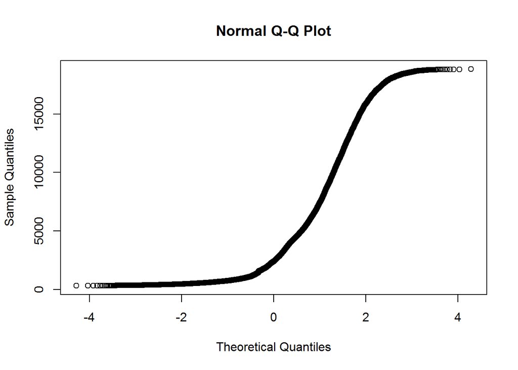

```r
library(ggplot2)
qqnorm(diamonds$price)
```

As we can see from the figure, the data here is not normally distributed.

We will now plot qqplot for logarithm of diamonds price.

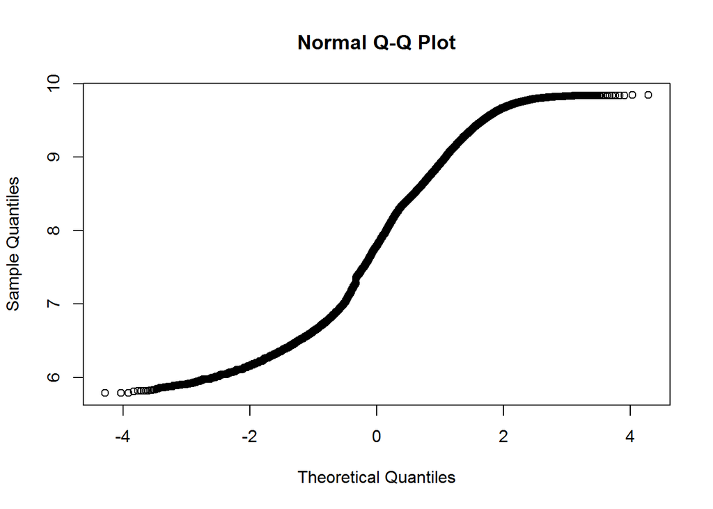

```r
qqnorm(log(diamonds$price))
```

The logarithmic plot can reveal the data clearly as compared to normal qqplot of actual values as the data is more sparse.

### Question 1.b

#### i) histogram of diamonds price

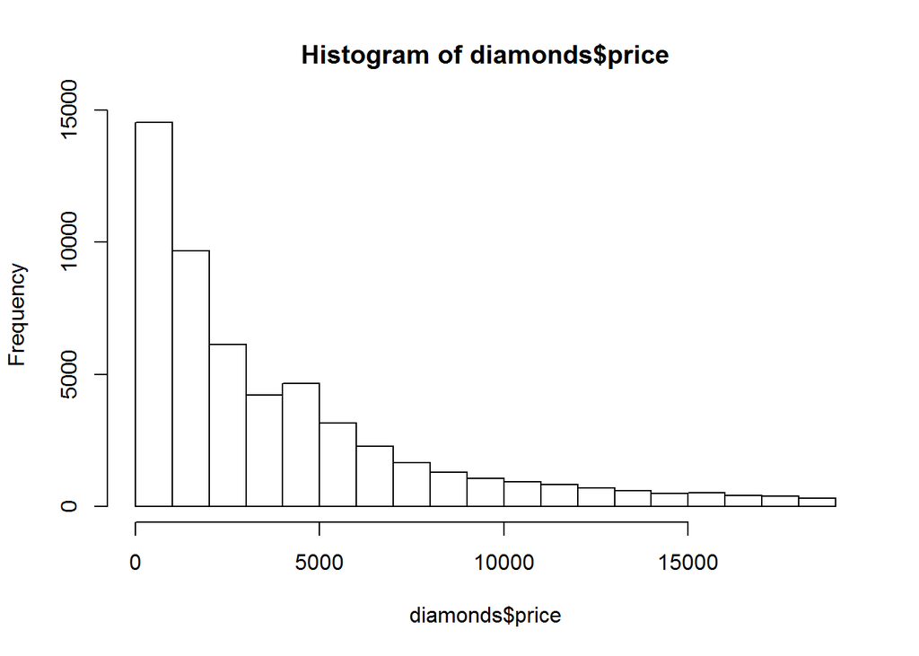

```r
hist(diamonds$price)
```

#### ii) Sample mean

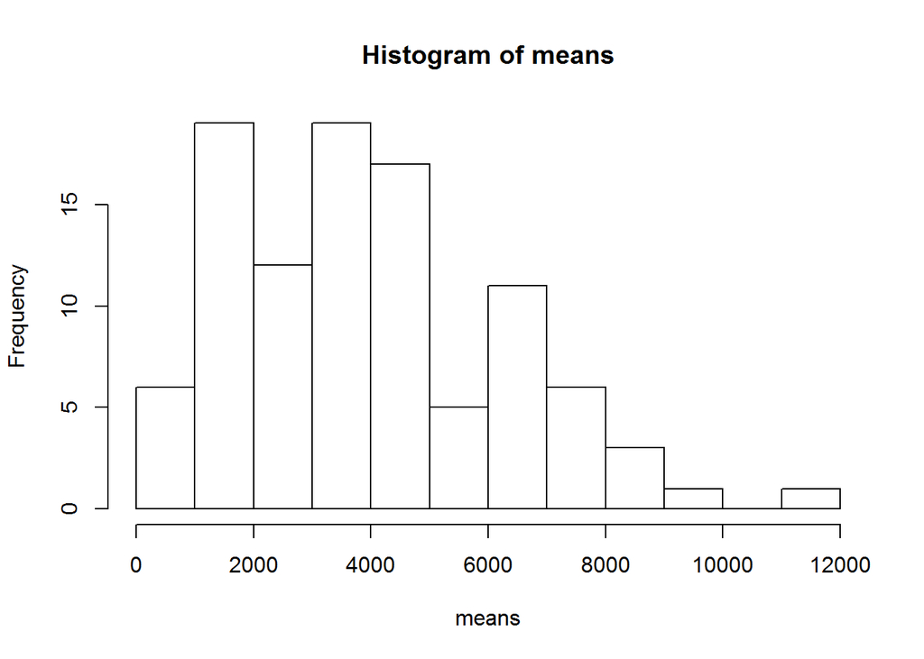

```r
means <- numeric(length = 0)
for(i in 1:100){
means[i]<-  mean(sample(diamonds$price,3,replace = FALSE))
}

hist(means)
```

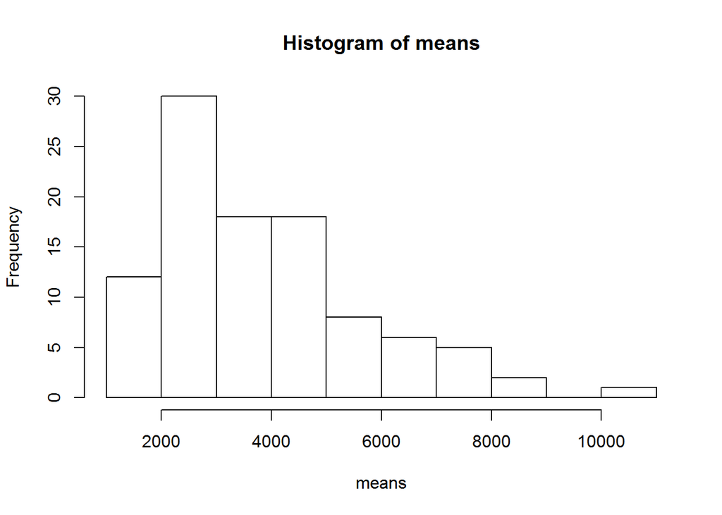

```r
#part iii
for(i in 1:100){
means[i]<-  mean(sample(diamonds$price,5,replace = FALSE))
}

hist(means)
```

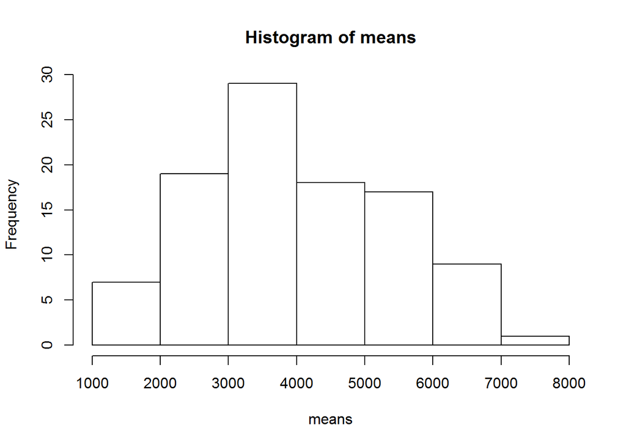

```r
for(i in 1:100){
means[i]<-  mean(sample(diamonds$price,10,replace = FALSE))
}

hist(means)
```

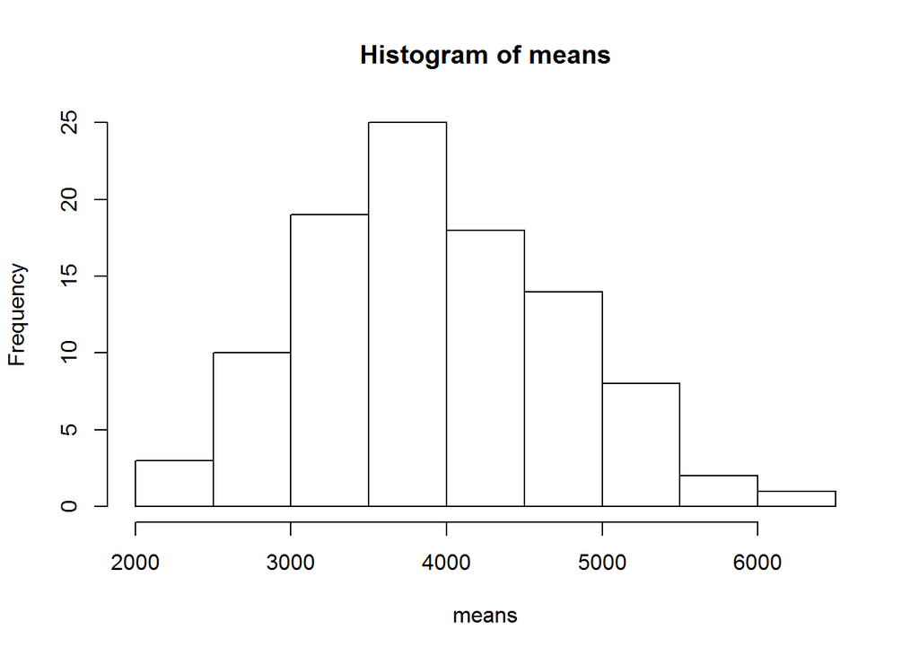

```r
for(i in 1:100){
means[i]<-  mean(sample(diamonds$price,20,replace = FALSE))
}

hist(means)
```

As we can see here plotting the means of random sample repeatedly will transform the histogram to normal distribution.

If we will increase the sample size of the dataset it will converge to normal distribution at much faster rate

#### Question 1.b.iv Logarithmic plot

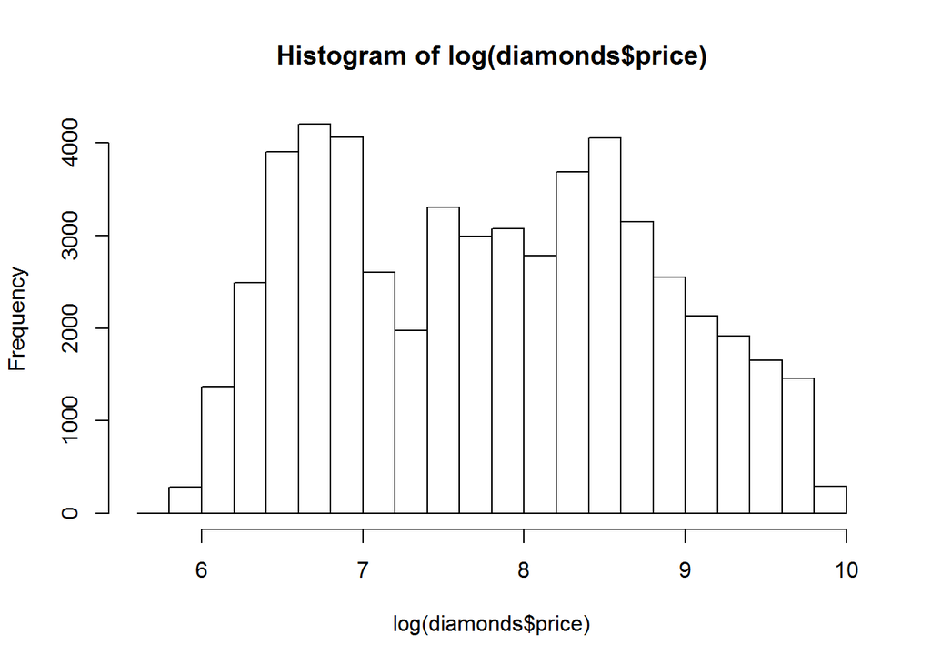

```r
hist(log(diamonds$price))
```

#### ii) Sample mean

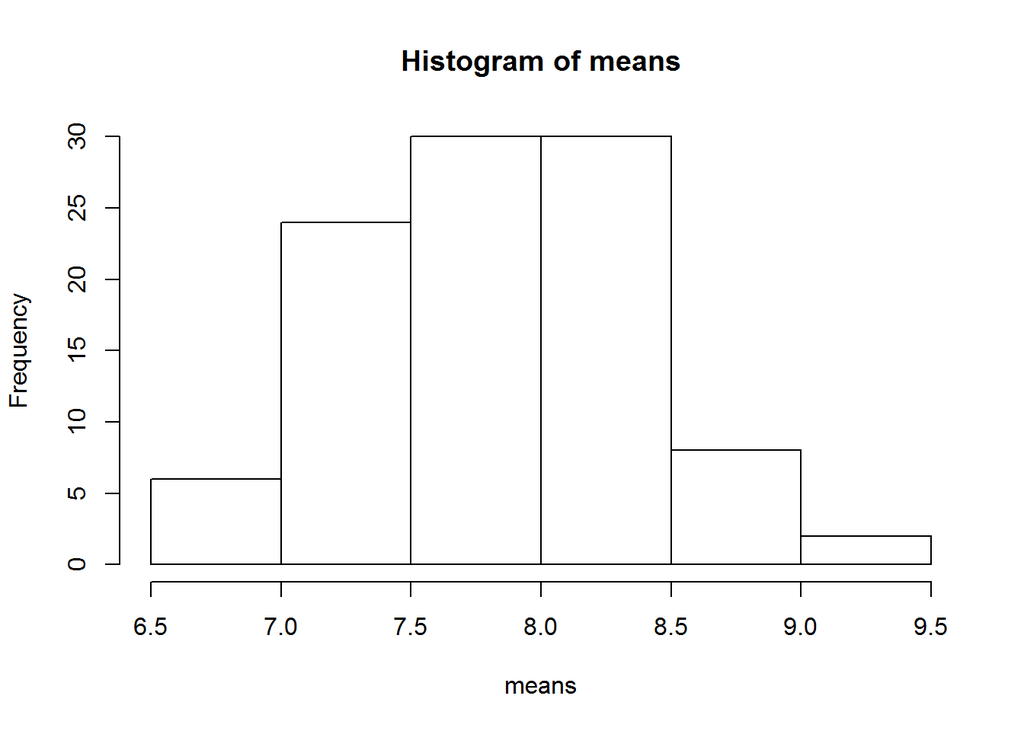

```r
means <- numeric(length = 0)
for(i in 1:100){
means[i]<-  mean(sample(log(diamonds$price),3,replace = FALSE))
}

hist(means)
```

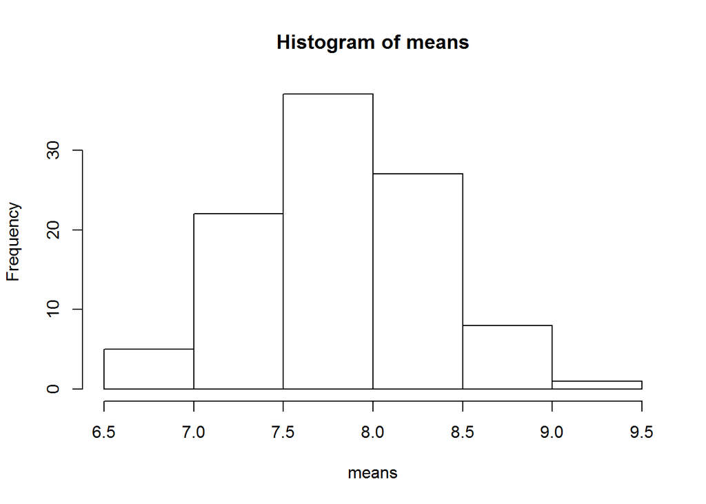

```r
#part iii
for(i in 1:100){
means[i]<-  mean(sample(log(diamonds$price),5,replace = FALSE))
}

hist(means)
```

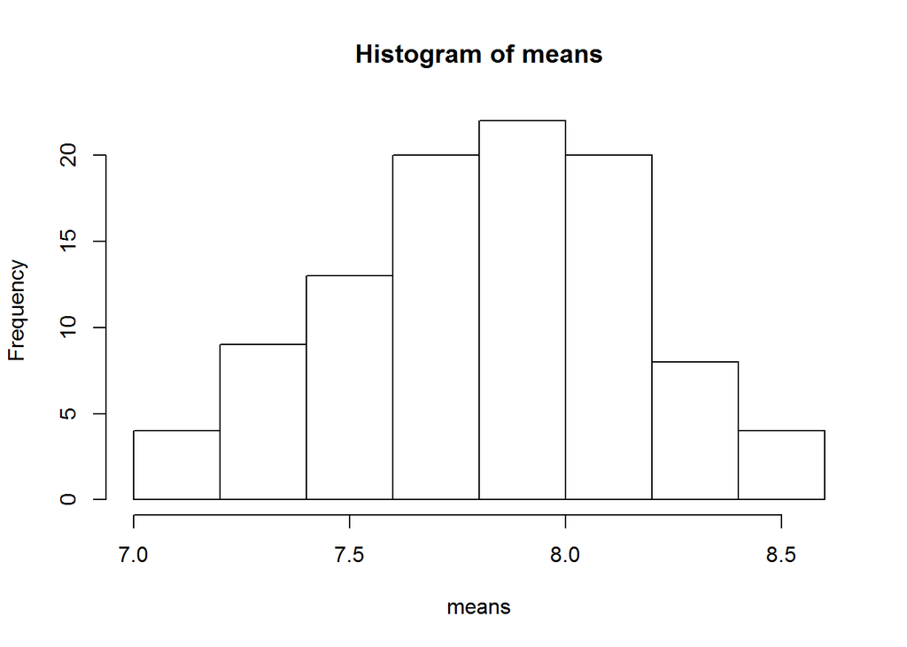

```r
for(i in 1:100){
means[i]<-  mean(sample(log(diamonds$price),10,replace = FALSE))
}

hist(means)
```

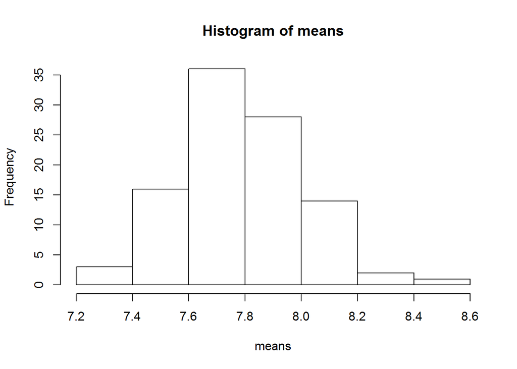

```r
for(i in 1:100){
means[i]<-  mean(sample(log(diamonds$price),20,replace = FALSE))
}

hist(means)
```

In the logarithmic plot of histogram we can see that even for smaller data set size calculating the sample mean, results in normal distribution faster.

### Question2

here it is given

n=25, $\mu = 65$ , $\sigma = 2.5$

Expected Value of sample distribution is same as population mean

hence Expected value=$\mu$ =65

Standard error (SE)= $\sigma / \sqrt n$ = 0.5

Also the shape of original distribution is normal and we are taking the sampling distribution of size 25.

#### Question 2 part b

We will convert $N(65,.5^2)$ into $N(0,1)$

so $Z = (X-\mu)/\sigma$ = $Z=(66-65)/.5$ =2

So (P>66) = (P>2)

= (1- .9772) (By Z table)

= 0.0228

We will convert $N(63,.5^2)$ into $N(0,1)$

so $Z = (X-\mu)/\sigma$ = $Z=(63-65)/.5$ =-4

So (P<63) = (P< -4)

=.000032(By Z table)

We will convert into $N(0,1)$

so $Z1=(63.5-65)/.5$ =-3

and $Z2=(66.5-65)/.5$ =3

so probablity is between P(-3) and P(+3)

which is equal to P(3) - P(-3) , we will use Z table to calculate probablity

= (.9987 - .0013) = 0.9974

#### Part c

According to the empirical rule we know that 95% of data comes under 2 standard deviation

So we have to calculate the interval between Z score of -2 to 2

that can be caluclated using the same formula

$Z = (X-\mu)/ \sigma$ => $X = Z*\sigma + \mu$

so for lower interval

X = (-2*.5+65) = 64

for upper interval X = (2*.5+65) = 66

So 95% data will be in interval [64 66]

#### Part D

Here the sample size is 1 since we are looking at the first girl.

hence, n=1 and $\sigma = 2.5 and \mu=65$

SE= 2.5/1 = 2.5

We will convert $N(66,2.5^2)$ into $N(0,1)$

so $Z = (X-\mu)/\sigma$ = $Z=(66-65)/2.5$ =0.4

So (P>66) = (P>0.4)

=(1-.6554)= .3446 (By Z table)

#### Part E

The difference in value is due to the sample size , in part b we have sample size of 25, so its standard error of sample varies according to the sample size.

### Question3

here it is given

n=100, $\mu = 65$ , $\sigma = 2.5$

Expected Value of sample distribution is same as population mean

hence Expected value=$\mu$ =65

Standard error (SE)= $\sigma / \sqrt n$ = 0.25

#### Question 3 part b

We will convert $N(65,.25^2)$ into $N(0,1)$

so $Z = (X-\mu)/\sigma$ = $Z=(66-65)/.25$ =4

So (P>66) = (P>4)

= .000032 (By Z table)

We will convert $N(63,.25^2)$ into $N(0,1)$

so $Z = (X-\mu)/\sigma$ = $Z=(63-65)/.25$ =-8

So (P<63) = (P< 8)

=0(By Z table)

We will convert into $N(0,1)$

so $Z1=(63.5-65)/.25$ =-6

and $Z2=(66.5-65)/.25$ =6

so probablity is between P(-6) and P(+6)

#### Part c

According to the empirical rule we know that 95% of data comes under 2 standard deviation

So we have to calculate the interval between Z score of -2 to 2

that can be caluclated using the same formula

$Z = (X-\mu)/\sigma$ => $X = Z\sigma + \mu$

so for lower interval

X = (-2*.25+65) = 64.5

for upper interval X = (2*.25+65) = 65.5

So 95% data will be in interval [64.5 65.5]

#### Part D

Here the sample size is 1 since we are looking at the first girl.

hence, n=1 and $\sigma = 2.5 and \mu=65$

SE= 2.5/1 = 2.5

We will convert $N(66,2.5^2)$ into $N(0,1)$

so $Z = (X-\mu)/\sigma$ = $Z=(66-65)/2.5$ =0.4

So (P>66) = (P>0.4)

=(1-.6554)= .3446 (By Z table)

#### Part E

The difference in value is due to the sample size , in part b we have sample size of 100, so its standard error of sample varies according to the sample size.

### Question4

#### Difference between Standard deviation and standard error

Standard deviation is the measure of deviation of data from the mean value

It is calculated as : $SD = \sqrt(\sum(Y(i)-y)^2 /N)$

Standard error is calculated for a sample data of population and it is standard deviation of sampling distribution

It is calculated as: $S.E = \sigma/\sqrt n$

For a given population standard deviation is always greater than standard error

### Question5

#### Relationship between standard error and size of sampler

let n be size of sample data $S.E = \sigma/\sqrt n$

With increasing sample size the standard error will tend to 0.

### Question6

#### Central Limit Theorem

Central limit theorem states that the sample mean of sufficiently large number of samples from a given population will be normally distributed. For e.g If we flip a coin very large number of times, the probablity of getting a given number of heads will follow a normal curve with mean equal to half the total number of flips.

Importance:

As we know that it is impossible to figure out mean of population ,the central limit theorem tells that sample mean will be close to poulation mean.

Apart from these there are certain characteristics of normal curve which can be applied to CLT such as Probablity density function,which can tell lot about the population.